# Projekt2

Piotr Weremczuk, Kamil Wirtek, Grzegorz Ziajka

## Wstęp

Choroby sklasyfikowane w ICD 10 pod symbolem C50_D05 to szeroko rozumiane nowotwory złośliwe piersi, z pominięciem raków skóry piersi. Według Krajowego Rejestru Nowotworów jest to najczęściej rozpoznawany wśród kobiet nowotwór złośliwy i druga najczęstsza przyczyna zgonów z powodów onkologicznych.

Celem naszej pracy jest stworzenie modelu, który dalej posłuży do prognozy ilośći przypadków nowotorów C50_D05 dla grup unikalnych pod względem powiatu, płci i grupy wiekowej na rok 2013.

## Dobór zmiennych objaśniających

Na tym etapie warto rozważyć korelacje Spearmana (rangową) dla zmiennych ilościowych.

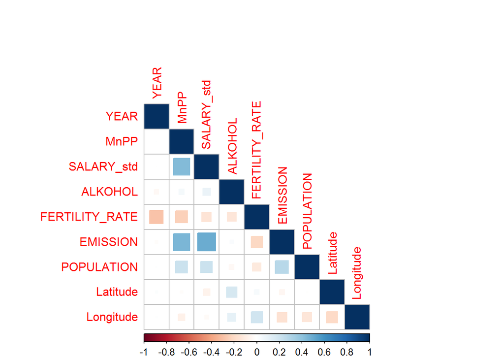

Na podstawie powyższego wykresu widzimy że korelacje między zmiennymi objaśniającymi są niewielkie i nie powinny stanowić problemu przy estymacji modelu.

Kolejnym krokiem jest sprawdzenie istotnośći wpływu na kształtowanie się ilości przypadków raka wymienionych zmiennych objaśniających. Przeprowadzone testy statystyczne nie odrzucają hipotezy o istotności tych zmiennych. Dla ograniczenia objętości raportu szczegółowe wyniki testu nie zostaną pokazane(są dostępne w raporcie z fazy 1). Interesujące jest jedynie pokazanie czytelnikowi istotności zmiennych geograficznych, tj. Longitude i Latitude. Dla ustalenia uwagi ograniczymy się do poziomu województw.

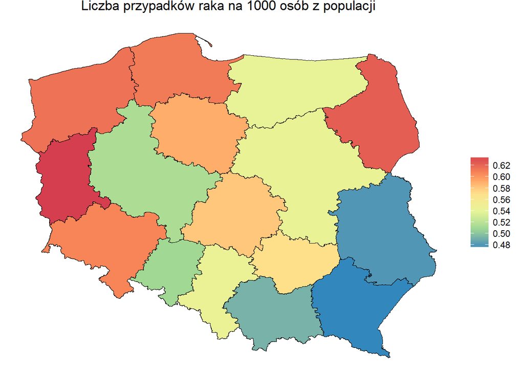

Powyższa mapa daje nam przypuszczenie o istnieniu autokorelacji przestrzennej zmiennej objaśnianej.Potwierdza to wynik testu Mantela:

Wynik testu autokorelacji przestrzennej Mantela

```
## Monte-Carlo test
## Observation: 0.3318003
## Call: mantel.rtest(m1 = voivodeship_dist, m2 = BRCA_dist, nrepet = 9999)
## Based on 9999 replicates
## Simulated p-value: 0.0046
```

## Trzy Podejścia

Do predykcji liczby przypadków nowotworu C50_D05 na rok 2013 wykorzystamy znane nam trzy modele: model liniowy, uogólniony model addytywny GAM oraz Las Losowy. Głównym kryterium porównawczym będzie błąd RMSE.

## Model Liniowy

Pierwszym rozważanym modelem będzie tradycyjny model lniowy. Ostateczna forma modelu (wybór zmiennych objaśniających) został dokonany z użyciem kryterium AIC.

Dla zbioru treningowego model prezentuje się następująco:

```
##
## Call:
## lm(formula = CASES/POPULATION ~ GENDER * (SALARY_std + MnPP +
##     ALKOHOL + AGE_GROUP), data = Train)
##
## Residuals:
##        Min         1Q     Median         3Q        Max
## -0.0019317 -0.0003656 -0.0000275  0.0002691  0.0103923
##
## Coefficients:
##                            Estimate Std. Error t value Pr(>|t|)
## (Intercept)               2.752e-04  5.848e-05   4.706 2.58e-06 ***
## GENDERM                  -1.640e-04  1.777e-04  -0.923 0.356017
## SALARY_std                4.460e-05  1.099e-05   4.058 5.02e-05 ***
## MnPP                      2.796e-04  2.891e-05   9.671  < 2e-16 ***
## ALKOHOL                  -3.225e-02  1.140e-02  -2.829 0.004692 **
## AGE_GROUP<45-54>          1.348e-03  3.440e-05  39.183  < 2e-16 ***
## AGE_GROUP<55-64>          1.897e-03  3.433e-05  55.265  < 2e-16 ***
## AGE_GROUP<65-74>          1.951e-03  3.443e-05  56.680  < 2e-16 ***
## AGE_GROUP<75-84>          1.548e-03  3.462e-05  44.716  < 2e-16 ***
## AGE_GROUP85+              1.614e-03  3.948e-05  40.881  < 2e-16 ***
## GENDERM:SALARY_std       -9.375e-05  2.475e-05  -3.788 0.000154 ***
## GENDERM:MnPP             -4.301e-04  7.035e-05  -6.115 1.03e-09 ***
## GENDERM:ALKOHOL           3.054e-02  3.011e-02   1.014 0.310471
## GENDERM:AGE_GROUP<45-54> -1.244e-03  1.329e-04  -9.362  < 2e-16 ***
## GENDERM:AGE_GROUP<55-64> -1.741e-03  1.212e-04 -14.369  < 2e-16 ***
## GENDERM:AGE_GROUP<65-74> -1.542e-03  1.213e-04 -12.706  < 2e-16 ***
## GENDERM:AGE_GROUP<75-84> -9.264e-04  1.256e-04  -7.378 1.83e-13 ***
## GENDERM:AGE_GROUP85+      5.849e-04  1.728e-04   3.384 0.000719 ***
## ---
## Signif. codes:  0 '***' 0.001 '**' 0.01 '*' 0.05 '.' 0.1 ' ' 1
##
## Residual standard error: 0.0007207 on 5774 degrees of freedom
## Multiple R-squared:  0.5278, Adjusted R-squared:  0.5264
## F-statistic: 379.6 on 17 and 5774 DF,  p-value: < 2.2e-16
```

Współczynnik dopasowania $R^{2}$ na poziomie 0.5278 jest niezadowalający. Jest to motywacją do skorzystania z modeli uogólnionych.

Dla zbioru testowego RMSE wynosi

```
## [1] 0.0007149587
```

- Obserwacje oddalone (outlier)
- Obserwacje wpływowe

Obserwacja odstająca (ang. outlier) jest obserwacją, która nie spełnia równania regresji czyli nie należy do modelu regresji. Obserwacje odstające mogą znacząco wpływać na postać prostej regresji.

Obserwacja jest wpływowa (ang. influential), jeśli jej obecność wpływa na prostą regresji, w taki sposób, że zmienia się współczynnik kierunkowy tej prostej. Innymi słowy, usunięcie tej obserwacji ze zbioru danych powoduje dużą zmianę wektora współczynników regresji. Obserwacje odstające mogą, ale nie muszą być obserwacjami wpływowymi.

Naszym celem jest identyfikacja obserwacji odstających i wpływowych

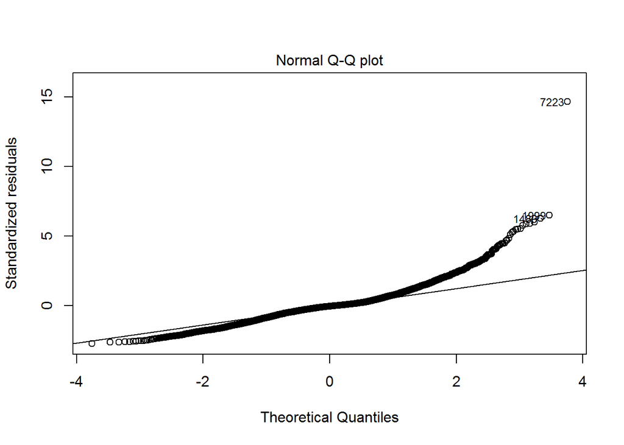

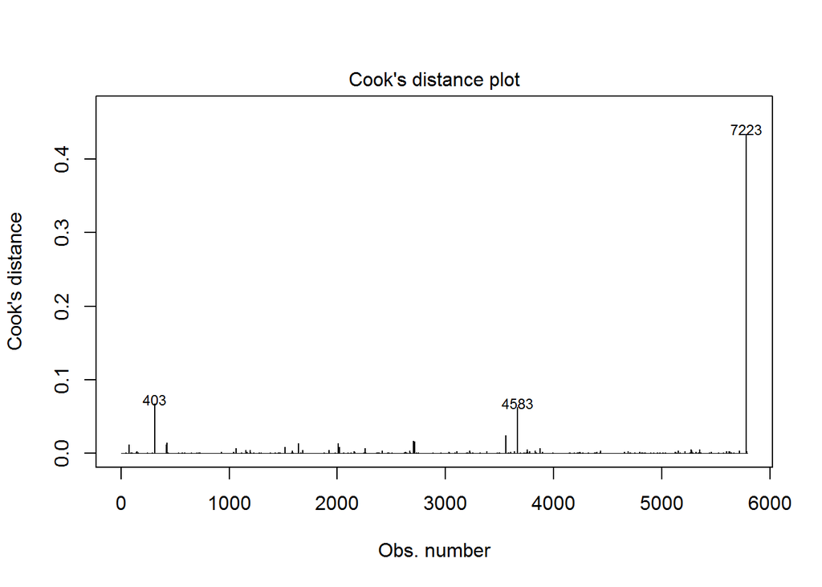

Mamy

```
## [1] 5
```

obserwacji odstających w zbiorze testowym

oraz

```
## [1] 804
```

obserwacji wpływowych w zbiorze testowym

## Uogólniony Model Addytywny GAM

Modele GAM mają postać:

g(E(Y|x_{i,1},…,x_{i,d}))= b + f_{1}(x_{i,1})+ ... +f_{d}(x_{i,d}) ,

gdzie:

- Y - zmienna objaśniana
- b - stała
- f_{j}, j=1 .... d to nieznane funkcje j-tej zmiennej objasniajacej estymowane m.in. przy pomocy wygładzonych kubicznych funkcji sklejanych.
- g - funkcja wiążąca średnią. Jej postać zależy od rozkładu zmiennej wynikowej

Estymacja funkcji f_{j}, j=1 .... d odbywa się jednocześnie za pomoca iteracyjnego algorytmu wielokrotnego dopasowywania. W modelach zmienna objaśniana Y należy do rodziny rozkładów wykładniczych.

Jak już wspomniano test Mantel wykazał zależność geograficzną dla zmiennej CASES. Modele GAM umożliwiają wygładzanie przestrzenne, np. za pomocą modelu cienkiej płytki (TPS).

## Thin Plate Spline

TPS to oparta na funkcjach sklejanych technika interpolacji oraz wygładzania danych. TPS ma swoje źródło w teorii fizycznej opisującej, jak zniekształcić cienką płytkę metalu, aby zminimalizować naprężenie tej płytki w wyniku nagięcia jej w pewnych punktach, co stanowi analogie interpolacji.

Zagadnienienie interpolacyjne polega na znalezieniu funkcji
$$\ f:R^{2} -> R$$

, która jak najlepiej interpoluje dane (x_i, y_i), ale przy zachowaniu jak największego stopnia wygładzenia w stosunku do wyjściowych punktów. Wprowadza się zatem parametr wygładzania k . Funkcja f jest wybrana tak, że nie koniecznie dokładnie interpoluje dane punkty, ale minimalizuje poniższe wyrażenie.

$$\ \sum_{i=1}^{n} \| f(x_{i})-y_{i} \|_{2}^{2} + k \int_{R^{2}} [(\frac{\partial ^{2}f(x_{1},x_{2})}{\partial x_{1}^{2}})^{2}\ +\ (\frac{\partial ^{2}f(x_{1},x_{2})}{\partial x_{1} \ \partial x_{2}})^{2} \ +\ (\frac{\partial ^{2}f(x_{1},x_{2})}{\partial x_{2}^{2}})^{2}\ ]\ dx$$

Można udowodnić, że funkcja f:R^{2}-> R , która minimalizuje powyższe wyrażenie ma postać:

$$f(x)\ \ =\ \sum_{i=1}^{n}\frac{y_{i}-f(x_{i})}{k} G(x,x_{i})\ +\ b_{0}+b_{1}x_{1}+b_{2}x_{2}$$

,gdzie:

- $G:R^2 \times R^{2} -> R$ - funkcja Green’a, która na $R^{2}$ przyjmuje postać $G(x,x_{i})=\|x-x_{i} \|_{2}^{2}\ ln(|x-x_{i} \|_{2})$
- $b=[b_{0},b_{1},b_{2}]= (N^{T}M^{-1}N)^{-1}N^{T}M^{-1}y$
- $M=(G(x_{i},x_{j}))_{i,j}$, N to macierz $n\times 3$ o wierszach $(1,x_{1,i},x_{2,i})$, a $y=[y_{1}\dots y_{n}]$

W naszym przypadku ramka danych $(y_{i},x_{i})_{i=1}^{n}$ przyjmuje postać y=CASES x=(Longitude, Latitude).

## Rozkład zmiennej CASES

Dla poprawnego użycia modelu GAM musimy zbadać rozkład naszej zmiennej CASES. Rozważymy trzy rozkłady: Poissona, Pascala oraz Tweedie. Porównanie tych rozkładów z rozkładem zmiennej CASES (oś x ma skalę logarytmiczną) prezentuje się następująco:

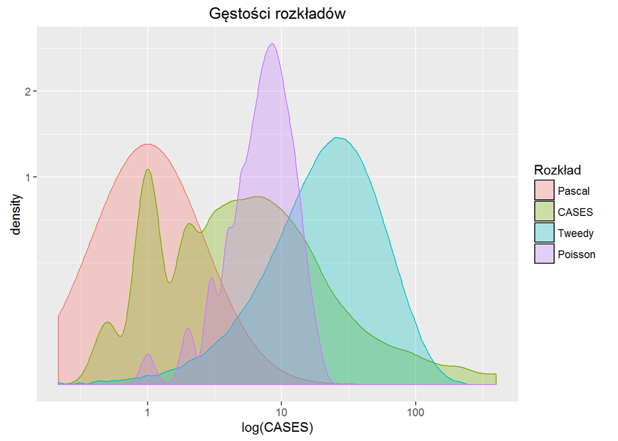

Naturalnym jest przyjęcie hipotezy że zmienna CASES pochodzi z rozkładu Poisonna. Jednak hipotezę tą można łatwo odrzucić porównując empiryczną wartość oczekiwaną i wariancję, które wynoszą odpowiednio:

```
## [1] 8.049392
```

```
## [1] 264.9242
```

Potwierdza to również test Kołomogorowa-Smirnova, przeprowadzony dla parametru równego zarówno empirycznej średniej i wariancji zmiennej CASES.

```
##
##  One-sample Kolmogorov-Smirnov test
##
## data:  dane_est$CASES
## D = 0.4109, p-value < 2.2e-16
## alternative hypothesis: two-sided
```

```
##
##  One-sample Kolmogorov-Smirnov test
##
## data:  dane_est$CASES
## D = 0.99884, p-value < 2.2e-16
## alternative hypothesis: two-sided
```

Z wykresu widzimy, że zmienna CASES znacząco odbiega od rozkładu Pascala. Potwierdza to test Kołomogorova-Smirnova.

```
##
##  One-sample Kolmogorov-Smirnov test
##
## data:  dane_est$CASES
## D = 0.98384, p-value < 2.2e-16
## alternative hypothesis: two-sided
```

Taki sam wynik otrzymamy roważając rozkład Tweedie. Wynik testu Kołomogorowa-Smirnova jest następujący.

```
##
##  One-sample Kolmogorov-Smirnov test
##
## data:  dane_est$CASES
## D = 0.7052, p-value < 2.2e-16
## alternative hypothesis: two-sided
```

## Tworzenie modeli

Powyższe badanie pokazało, że zmienna CASES nie pochodzi z roważanych rozkładów prawdopodobieństwa(Poisson, Pascal, Tweedoe). Jednakże dokonamy estymacji modeli GAM dla powyższych rodzin. Jako kryterium porównawcze wykorzystamy rozkłady RMSE tych modeli.

Po procesie doboru zmiennych objaśniających, otrzymano następującą formułę modelu:

FREQUENCY = GENDER * (AGE GROUP + MnPP + SALARY + YEAR) + s(FERTILITY RATE) + s(LATITUDE, LONGITUDE)

Szczegółowe parametry modelów GAM z rodziną Poissona, Pascala i Tweedie prezentują się następująco:

Poisson

```
##
## Family: poisson
## Link function: log
##
## Formula:
## CASES/POPULATION ~ GENDER * (AGE_GROUP + MnPP + SALARY + YEAR) +
##     s(FERTILITY_RATE, k = 11) + s(Latitude, Longitude, bs = "tp")
##
## Parametric coefficients:
##                            Estimate Std. Error z value Pr(>|z|)
## (Intercept)               4.601e+00  1.274e+01   0.361 0.717930
## GENDERM                  -1.972e+02  7.563e+01  -2.608 0.009119 **
## AGE_GROUP<45-54>          2.169e+00  1.784e-02 121.521  < 2e-16 ***
## AGE_GROUP<55-64>          2.494e+00  1.690e-02 147.540  < 2e-16 ***
## AGE_GROUP<65-74>          2.550e+00  1.811e-02 140.848  < 2e-16 ***
## AGE_GROUP<75-84>          2.329e+00  1.987e-02 117.204  < 2e-16 ***
## AGE_GROUP85+              2.193e+00  3.235e-02  67.798  < 2e-16 ***
## MnPP                      1.615e-01  1.345e-02  12.000  < 2e-16 ***
## SALARY                    5.490e-05  1.149e-05   4.778 1.77e-06 ***
## YEAR                     -6.701e-03  6.337e-03  -1.057 0.290296
## GENDERM:AGE_GROUP<45-54> -5.770e-01  1.685e-01  -3.424 0.000617 ***
## GENDERM:AGE_GROUP<55-64> -4.773e-01  1.520e-01  -3.139 0.001694 **
## GENDERM:AGE_GROUP<65-74>  2.855e-01  1.528e-01   1.868 0.061736 .
## GENDERM:AGE_GROUP<75-84>  8.026e-01  1.577e-01   5.088 3.62e-07 ***
## GENDERM:AGE_GROUP85+      1.820e+00  2.339e-01   7.779 7.33e-15 ***
## GENDERM:MnPP             -6.001e-01  8.211e-02  -7.309 2.70e-13 ***
## GENDERM:SALARY           -4.942e-04  6.510e-05  -7.591 3.17e-14 ***
## GENDERM:YEAR              9.791e-02  3.763e-02   2.601 0.009283 **
## ---
## Signif. codes:  0 '***' 0.001 '**' 0.01 '*' 0.05 '.' 0.1 ' ' 1
##
## Approximate significance of smooth terms:
##                          edf Ref.df Chi.sq p-value
## s(FERTILITY_RATE)      5.859  7.135  13.59  0.0663 .
## s(Latitude,Longitude) 22.863 26.833 302.61  <2e-16 ***
## ---
## Signif. codes:  0 '***' 0.001 '**' 0.01 '*' 0.05 '.' 0.1 ' ' 1
##
## R-sq.(adj) =  0.834   Deviance explained = 90.5%
## UBRE = -0.022883  Scale est. = 1         n = 5792
```

Pascal

```
##
## Family: Negative Binomial(25450.36)
## Link function: log
##
## Formula:
## CASES/POPULATION ~ GENDER * (AGE_GROUP + MnPP + SALARY + YEAR) +
##     s(FERTILITY_RATE, k = 11) + s(Latitude, Longitude, bs = "tp")
##
## Parametric coefficients:
##                            Estimate Std. Error z value Pr(>|z|)
## (Intercept)               2.279e+00  1.259e+01   0.181  0.85637
## GENDERM                  -1.967e+02  7.558e+01  -2.603  0.00925 **
## AGE_GROUP<45-54>          2.168e+00  1.784e-02 121.547  < 2e-16 ***
## AGE_GROUP<55-64>          2.494e+00  1.690e-02 147.583  < 2e-16 ***
## AGE_GROUP<65-74>          2.551e+00  1.810e-02 140.925  < 2e-16 ***
## AGE_GROUP<75-84>          2.329e+00  1.987e-02 117.230  < 2e-16 ***
## AGE_GROUP85+              2.194e+00  3.234e-02  67.836  < 2e-16 ***
## MnPP                      1.639e-01  1.320e-02  12.411  < 2e-16 ***
## SALARY                    5.748e-05  1.110e-05   5.180 2.22e-07 ***
## YEAR                     -5.550e-03  6.265e-03  -0.886  0.37567
## GENDERM:AGE_GROUP<45-54> -5.774e-01  1.685e-01  -3.427  0.00061 ***
## GENDERM:AGE_GROUP<55-64> -4.775e-01  1.520e-01  -3.141  0.00168 **
## GENDERM:AGE_GROUP<65-74>  2.855e-01  1.528e-01   1.868  0.06175 .
## GENDERM:AGE_GROUP<75-84>  8.038e-01  1.577e-01   5.096 3.47e-07 ***
## GENDERM:AGE_GROUP85+      1.820e+00  2.339e-01   7.781 7.18e-15 ***
## GENDERM:MnPP             -5.989e-01  8.206e-02  -7.299 2.90e-13 ***
## GENDERM:SALARY           -4.934e-04  6.499e-05  -7.591 3.18e-14 ***
## GENDERM:YEAR              9.765e-02  3.761e-02   2.597  0.00941 **
## ---
## Signif. codes:  0 '***' 0.001 '**' 0.01 '*' 0.05 '.' 0.1 ' ' 1
##
## Approximate significance of smooth terms:
##                          edf Ref.df  Chi.sq p-value
## s(FERTILITY_RATE)      1.032  1.062   2.562   0.111
## s(Latitude,Longitude) 20.062 24.748 316.062  <2e-16 ***
## ---
## Signif. codes:  0 '***' 0.001 '**' 0.01 '*' 0.05 '.' 0.1 ' ' 1
##
## R-sq.(adj) =  0.833   Deviance explained = 8.09%
## -REML = 6.2034e+05  Scale est. = 1         n = 5792
```

Tweedie

```
##
## Family: Tweedie(p=1.781)
## Link function: log
##
## Formula:
## CASES/POPULATION ~ GENDER * (AGE_GROUP + MnPP + SALARY + YEAR) +
##     s(FERTILITY_RATE) + s(Latitude, Longitude, bs = "tp")
##
## Parametric coefficients:
##                            Estimate Std. Error  t value Pr(>|t|)
## (Intercept)              -1.669e+01  1.601e-01  -104.28   <2e-16 ***
## GENDERM                  -3.479e+02  4.529e-01  -768.09   <2e-16 ***
## AGE_GROUP<45-54>          2.175e+00  1.684e-04 12920.26   <2e-16 ***
## AGE_GROUP<55-64>          2.501e+00  1.611e-04 15517.94   <2e-16 ***
## AGE_GROUP<65-74>          2.553e+00  1.954e-04 13065.78   <2e-16 ***
## AGE_GROUP<75-84>          2.331e+00  2.212e-04 10536.48   <2e-16 ***
## AGE_GROUP85+              2.213e+00  4.273e-04  5179.18   <2e-16 ***
## MnPP                      1.508e-01  1.701e-04   886.75   <2e-16 ***
## SALARY                    8.722e-05  1.485e-07   587.34   <2e-16 ***
## YEAR                      3.841e-03  7.964e-05    48.23   <2e-16 ***
## GENDERM:AGE_GROUP<45-54> -5.521e-01  5.943e-04  -928.94   <2e-16 ***
## GENDERM:AGE_GROUP<55-64> -4.203e-01  4.982e-04  -843.56   <2e-16 ***
## GENDERM:AGE_GROUP<65-74>  3.829e-01  5.843e-04   655.27   <2e-16 ***
## GENDERM:AGE_GROUP<75-84>  8.991e-01  6.942e-04  1295.20   <2e-16 ***
## GENDERM:AGE_GROUP85+      1.771e+00  1.987e-03   891.15   <2e-16 ***
## GENDERM:MnPP             -6.723e-01  4.759e-04 -1412.82   <2e-16 ***
## GENDERM:SALARY           -5.515e-04  3.362e-07 -1640.60   <2e-16 ***
## GENDERM:YEAR              1.729e-01  2.253e-04   767.36   <2e-16 ***
## ---
## Signif. codes:  0 '***' 0.001 '**' 0.01 '*' 0.05 '.' 0.1 ' ' 1
##
## Approximate significance of smooth terms:
##                         edf Ref.df      F p-value
## s(FERTILITY_RATE)      9.00      9  23493  <2e-16 ***
## s(Latitude,Longitude) 28.99     29 103491  <2e-16 ***
## ---
## Signif. codes:  0 '***' 0.001 '**' 0.01 '*' 0.05 '.' 0.1 ' ' 1
##
## R-sq.(adj) =  0.826   Deviance explained = 90.4%
## -REML = -4.0702e+08  Scale est. = 0.031035  n = 5792
```

Las losowy

```
## Random Forest
##
## 5792 samples
##   14 predictor
##
## No pre-processing
## Resampling: Cross-Validated (4 fold)
## Summary of sample sizes: 4344, 4344, 4344, 4344
## Resampling results across tuning parameters:
##
##   mtry  RMSE          Rsquared
##     2   0.0010041830  0.2052175
##   193   0.0007412412  0.5048806
##   385   0.0007437606  0.5037731
##
## RMSE was used to select the optimal model using  the smallest value.
## The final value used for the model was mtry = 193.
```

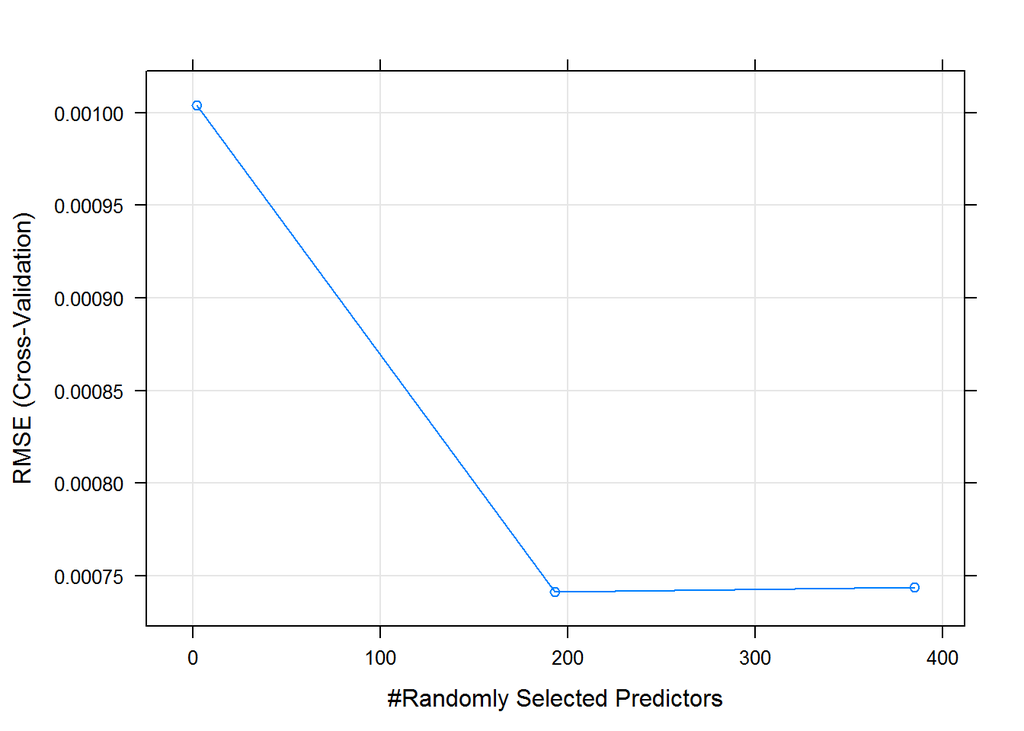

## Wybór ostatecznego Modelu

Przeprowadziliśmy procedure powtarzanej k-krotnej walidacji krzyżowej (repeated k-fold cross validation) otrzymaliśmy empiryczne rozkłady błędu (RMSE). Liczba powtórzeń wyniosła 250, natomiast k=4.

Wybór modelu będzie oparty na porównaniu ich rozkładu RMSE. Jednak ograniczymy się do modelu z Poissona i Pascala, ponieważ wygenerowanie odpowiedniej ilości RMSE dla modelu GAM z rodziną Tweedie jest zbyt czasochłonne pod względem obliczeniowym (również po zrównolegleniu obliczeń). Las losowy odrzucamy jako finalny model ze względu na brak interpretowalności.

Poniższy wykres porównuje gęstości rozkładu RMSE dla GAM z rodziną Pascala i Poissona :

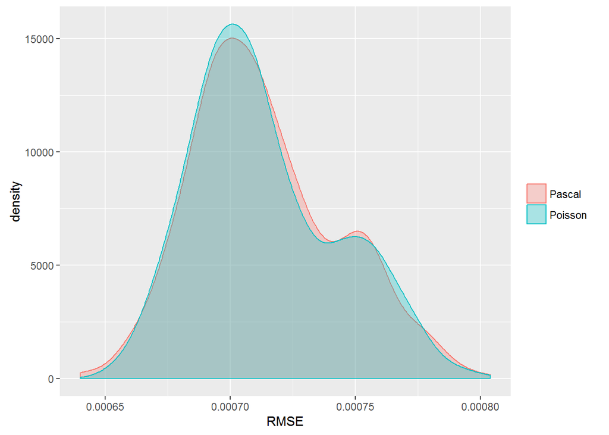

Widać, że rozkład RMSE dla rodziny Pascala jest “trochę” bardziej prawoskośny oraz ma grubsze ogony. Świadczy to o gorszej jakości modelu z taką rodziną. Ostateczną decyzje podejmujemy konfrontując ze sobą parametry rozkładów (średnią i wariancję).

```
##                 Mean     Variance
## Pascal  0.0007138727 8.555824e-10
## Poisson 0.0007136483 8.393051e-10
```

Wartości oczekiwane rozkładów RMSE dla obu rodzin są podobne, dlatego jako ostateczny model do prognozy wybieramy ten, gdzie wariancja RMSE jest najniższa, czyli GAM z rodziną poissonowską.

## Omówienie ostatecznego modelu

W wyniku przeprowadzonej procedury powtarzanej k-krotnej walidacji krzyżowej (repeated k-fold cross validation) otrzymaliśmy empiryczne rozkłady parametrów modelu odpowiadających kolejnym zmiennym objaśniającym. Prezentujemy je poniżej.

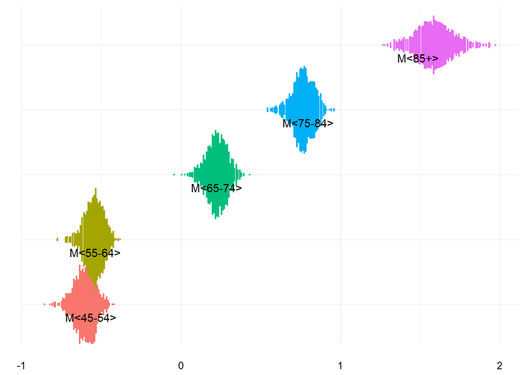

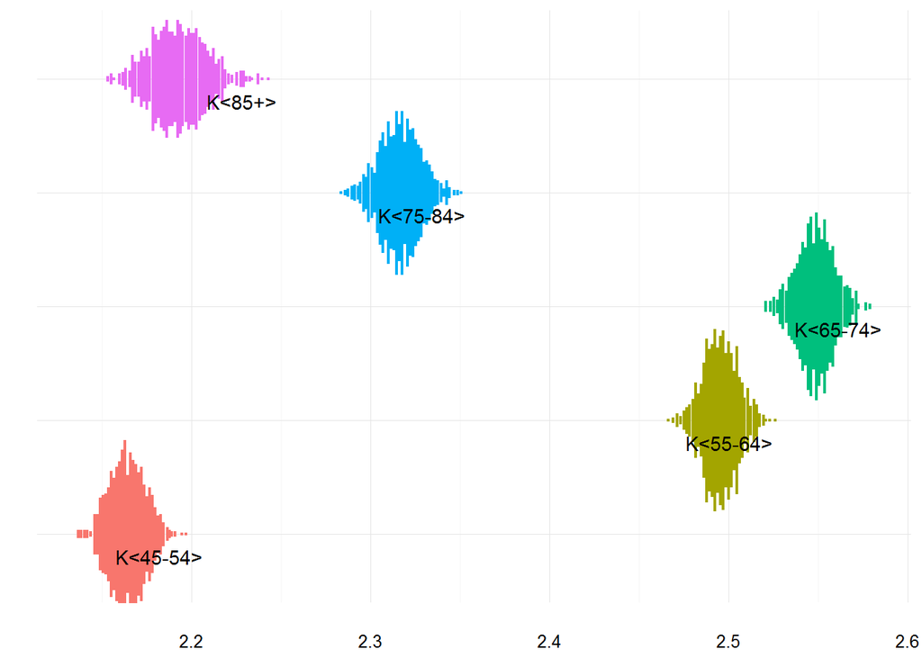

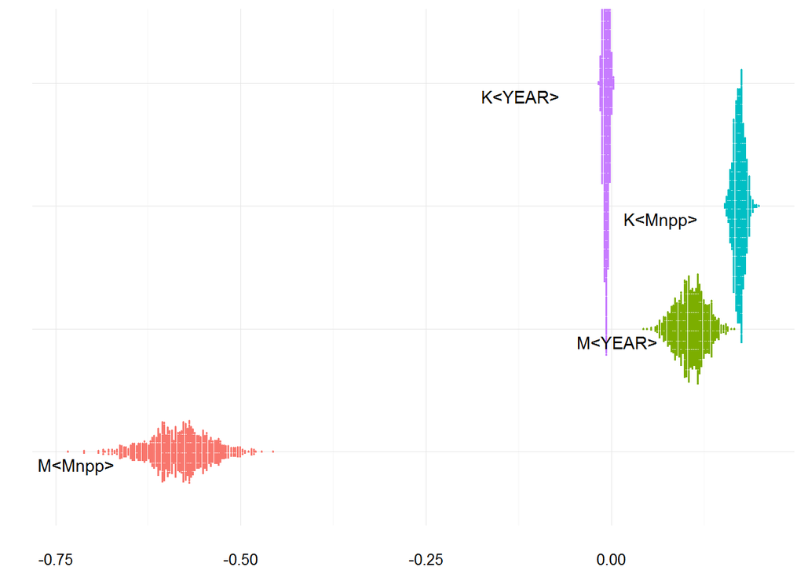

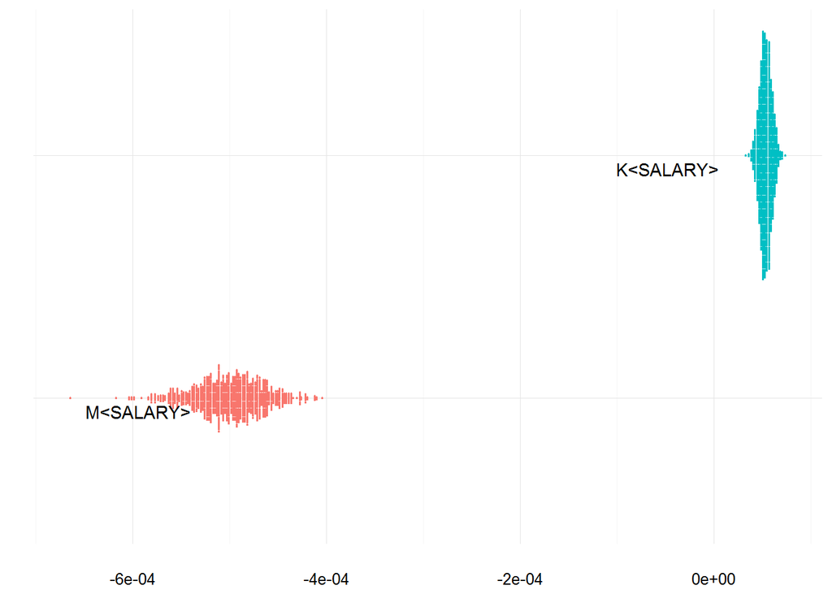

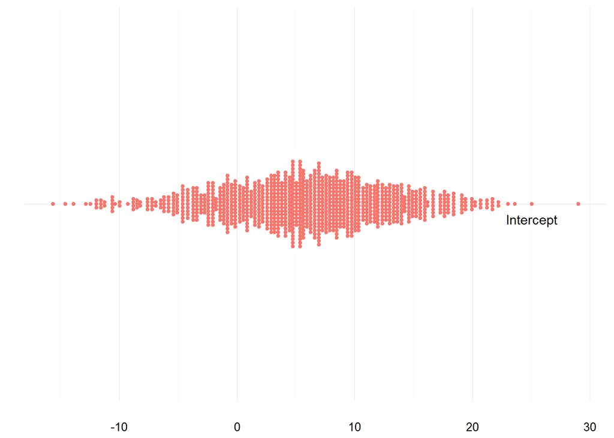

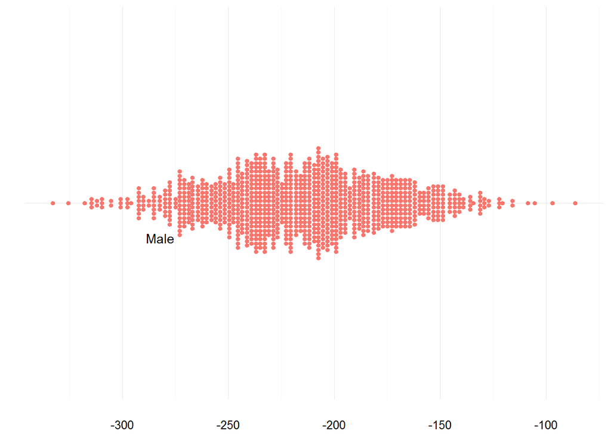

Analiza rozkładów parametrów otrzymanego modelu pozwala wyciągnąć wnioski na temat wpływu poszczególnych zmiennych objaśniających na predykcję. Zacznijmy od parametrów dotyczących grup wiekowych: Istnieje znacząca różnica między rozkładami poszczególnych parametrów modelu dla kobiet i mężczyzn, co potwierdza słuszność zastosowania interakcji zmiennych objaśniających z płcią. U kobiet najwyższa częstość zachorowań przypada na wiek <65-74>, u mężczyzn natomiast wzrasta po 65 roku życia. Podobnie w przypadku miast na prawach powiatu gdzie u kobiet obserwujemy nieco wyższą częstość, natomiast u mężczyzn istotnie niższą niż w powiatach ziemskich. Zmienna rok obserwacji nie okazała się istotna dla kobiet, jednak pozostała w modelu ze względu na obserwowany trend dla mężczyzn – częstość zachorowań wzrastała w kolejnych latach obserwacji. W końcu, dla kobiet częstość delikatnie wzrasta wraz ze wzrostem przeciętnego wynagrodzenia, u mężczyzn odwrotnie – spada. Warto zauważyć, że bazowa częstość zachorowań dla mężczyzn jest dużo niższa niż przeciętna.

Poniżej prezentujemy wykres przedstawiający porównanie wartości rzeczywistych z prognozowanymi.

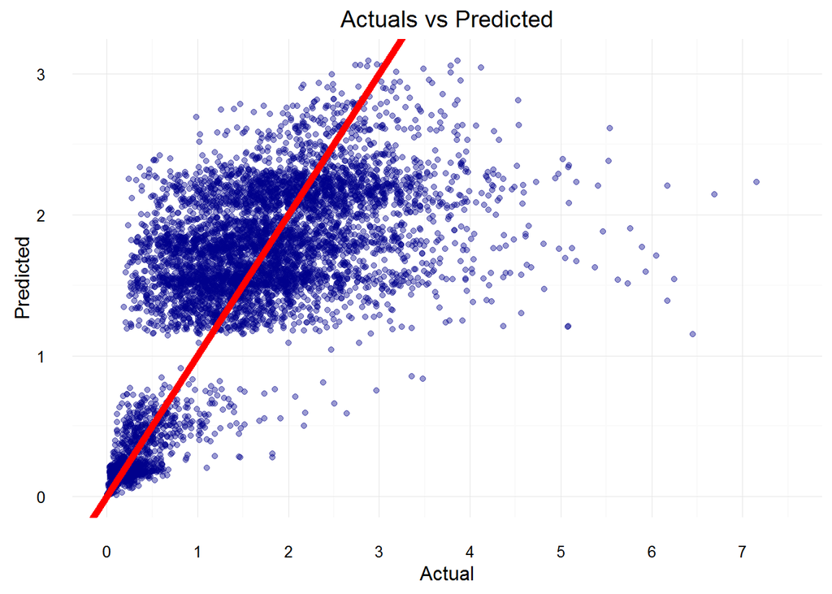